# ALHE_Raport

### ALHE - VNS Search

#### Autorzy

Paweł Andruszkiewicz, Kacper Harasim

### Funkcja kwadratowa

Do testów wykorzystaliśmy funkcję 1 z pakietu CEC. Jest to funkcja wyrażona wzorem:

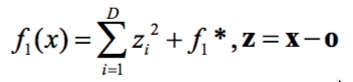

Wykres w przestrzeni 2D wygląda następująco:

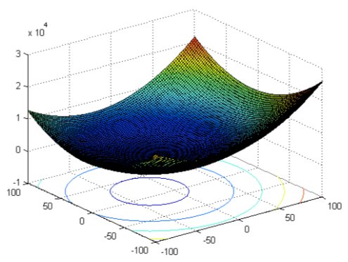

Algorytm dla problemu funkcji kwadratowej ustawiony został z następującymi parametrami: * kMax = 50 * iterMax = 500 * liczba wymiarów * wyszukiwania lokalne = 50 * wymiarów * gęstość przeszukiwania (zmiana odchylenia standardowego w zależności od k) = 0.25

Dla funkcji zostało dobrane stosunkowo niewielkie kMax, ponieważ jest to funkcja z wyłącznie jednym minimum lokalnym.

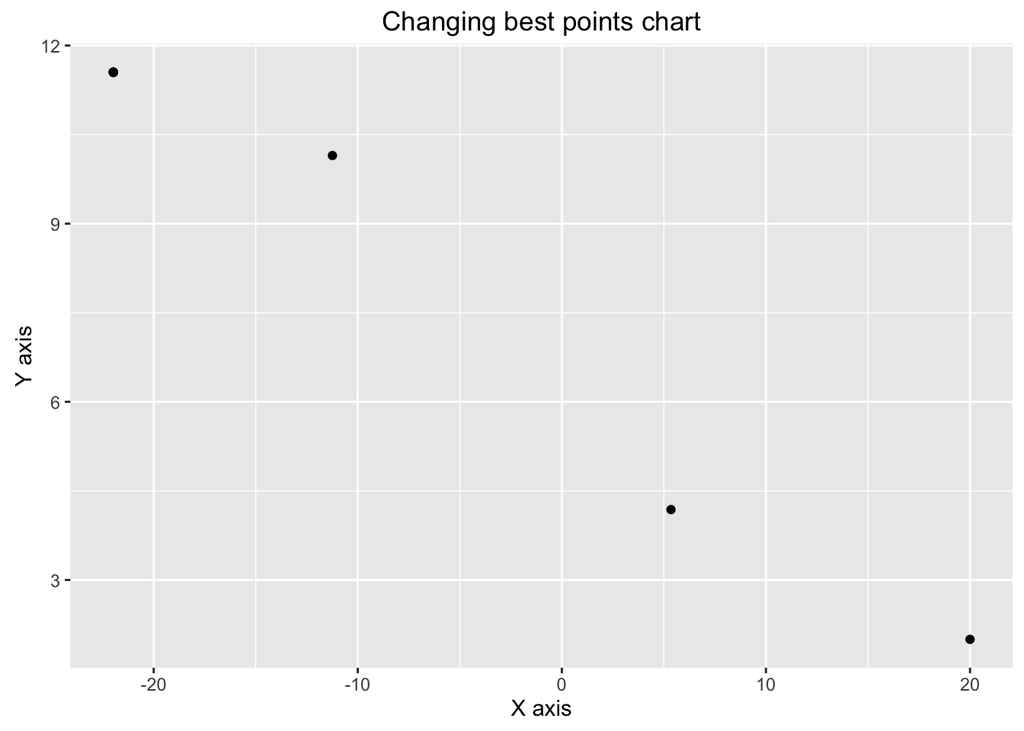

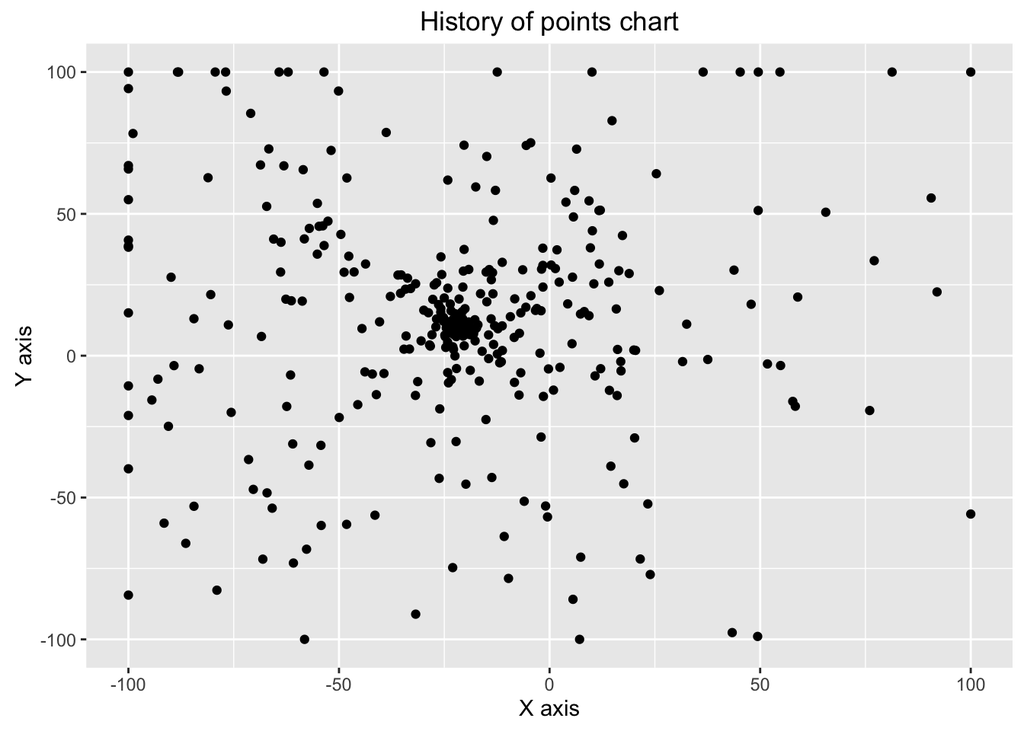

Wykres jakości od numeru iteracji:

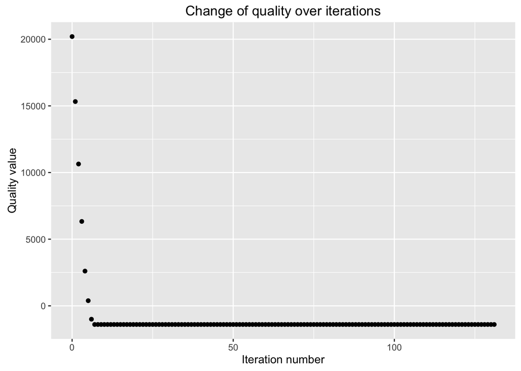

Na wykresie ostatnim możemy zauważyć, że minimum jest osiągane bardzo szybko.

Wykonaliśmy po 5 pomiarów błędów dla funkcji w każdym wymiarze.

##### 2 wymiary

```
## Średni błąd wyniósł:  1.427629e-05
```

|  | Result | Error | Relative error |
| --- | --- | --- | --- |
| 1 | -1400 | 4.80e-06 | 0 |
| 2 | -1400 | 2.49e-05 | 0 |
| 3 | -1400 | 3.32e-05 | 0 |
| 4 | -1400 | 1.50e-06 | 0 |
| 5 | -1400 | 7.00e-06 | 0 |

Dla 2 wymiarów algorytm niemalże bezbłędnie i bardzo szybko znajduje minimum globalne. Błąd jest minimalny.

##### 5 wymiarów

```
## Średni błąd wyniósł:  0.02591837
```

|  | Result | Error | Relative error |
| --- | --- | --- | --- |
| 1 | -1399.986 | 0.0136065 | 9.70e-06 |
| 2 | -1399.975 | 0.0248356 | 1.77e-05 |
| 3 | -1399.971 | 0.0290189 | 2.07e-05 |
| 4 | -1399.960 | 0.0403757 | 2.88e-05 |
| 5 | -1399.978 | 0.0217552 | 1.55e-05 |

Dla 5 wymiarów algorytm zachowuje się podobnie jak dla dwóch, wyniki są satysfakcjonujące.

##### 20 wymiarów

```
## Średni błąd wyniósł:  2.164323
```

|  | Result | Error | Relative error |
| --- | --- | --- | --- |
| 1 | -1397.512 | 2.487820 | 0.0017770 |
| 2 | -1398.128 | 1.871551 | 0.0013368 |
| 3 | -1397.599 | 2.400654 | 0.0017148 |
| 4 | -1397.867 | 2.132882 | 0.0015235 |
| 5 | -1398.071 | 1.928706 | 0.0013776 |

Dla 20 wymiarów błąd jest nieco większy, choć nadal akceptowalny.

##### 20 wymiarów z modyfikacjami

Zmodyfikowaliśmy parametry tak, aby przeszukiwać przestrzeń mniejszymi krokami. Parametry zostały zmodyfikowane: kmax podniesione do 250, a krok pomniejszony do 0.05. Rezultat był następujący:

```
## Średni błąd wyniósł:  1.395854
```

|  | Result | Error | Relative error |
| --- | --- | --- | --- |
| 1 | -1398.494 | 1.505895 | 0.0010756 |
| 2 | -1398.833 | 1.166864 | 0.0008335 |
| 3 | -1398.871 | 1.128788 | 0.0008063 |
| 4 | -1398.914 | 1.086495 | 0.0007761 |
| 5 | -1397.909 | 2.091228 | 0.0014937 |

Jak widzimy, zmiany nie są zbyt duże w stosunku do pierwowzoru.

#### Wnioski

Dla funkcji kwadratowej algorytm sprawdza się bardzo dobrze. Dla 20 wymiarów możemy zaobserwować większe błędy. Prawdopodobnie, gdyby zmniejszać coraz bardziej odchylenie standardowe rozkładu normalnego, funkcja wreszcie doszłaby do swojego optimum w 20 wymiarach. Zajęłoby to jednak znacznie więcej czasu.

Wynik dla funkcji kwadratowej uważamy za jak najbardziej satysfakcjonujący.

### Rotated Ackley’s Function - CEC8

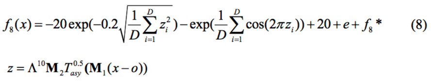

Do drugiego testu wybraliśmy benchmark 8 z pakietu CEC. Funkcja jest asymetryczna, oraz multimodalna. Ma ona wiele optimów lokalnych, więc uznaliśmy że nada się do przetestowania naszego algorytmu. Zwracamy uwagę przede wszystkim na umiejętność jej wychodzenia z tych optimów i dążenie do optimum globalnego.

Wykres 3-D funkcji:

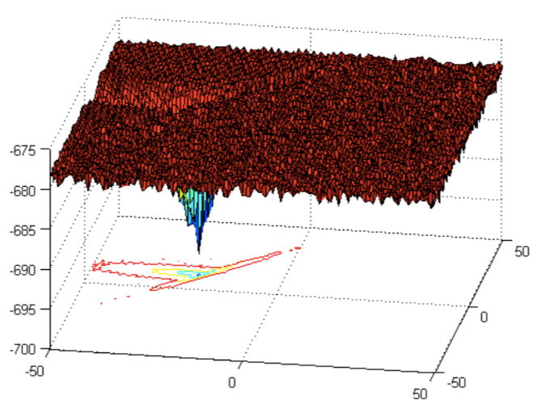

Mapa konturowa funkcji:

[figure not shown]

Widzimy, że globalne optimum znacznie różni się od innych lokalnych optimów. W związku z tym celem algorytmu jest znalezienie się w otoczeniu globalnego optimum. Gdy już się tam znajdzie - powinien on jak najszybciej zacząć zbiegać ku niemu

Algorytm dla problemu ustawiony został z następującymi parametrami: * kMax = 500 dla 2 wymiarów, 1000 dla większej liczby * iterMax = 1000 * liczba wymiarów * wyszukiwania lokalne = 50 * liczba wymiarów * gęstość przeszukiwania (zmiana odchylenia standardowego w zależności od k) = 0.25 dla 2 wymiarów, 0.1 dla większej liczby

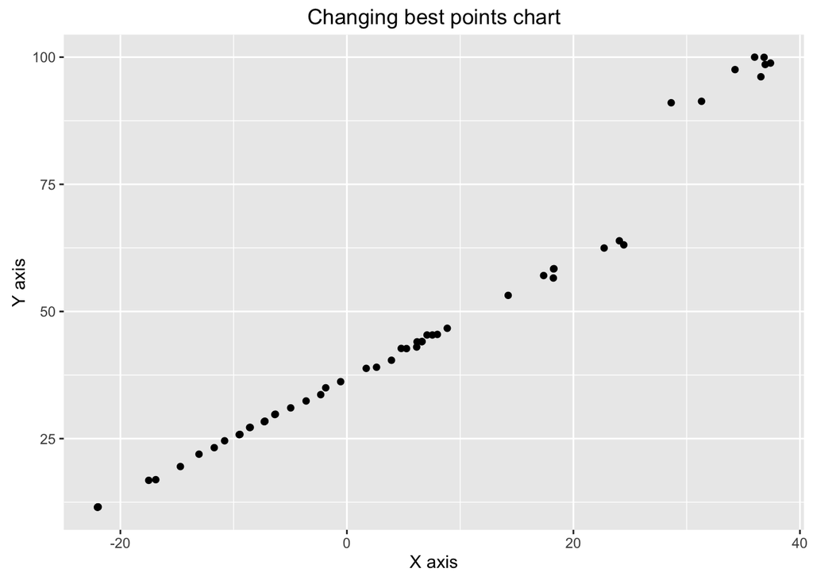

Na tym przykładzie dobrze widać jak ważne w tego typu algorytmach są tzw. “strategie naprawcze”. My stosujemy proste rzutowanie na granicę zbioru dopuszczalnego. Rozwiązanie to ma swoje wady i zalety. Jako wadę można przytoczyć słabe pokrycie bliskiej okolicy granic. Inaczej sytuacja ma się w przypadku samych granic. Gdyby optimum było w takim miejscu, nie zostałoby ono ominięte przez algorytm, podczas gdy wiele innych algorytmów znacznie zawęża możliwość trafienia w punkt “w rogu”

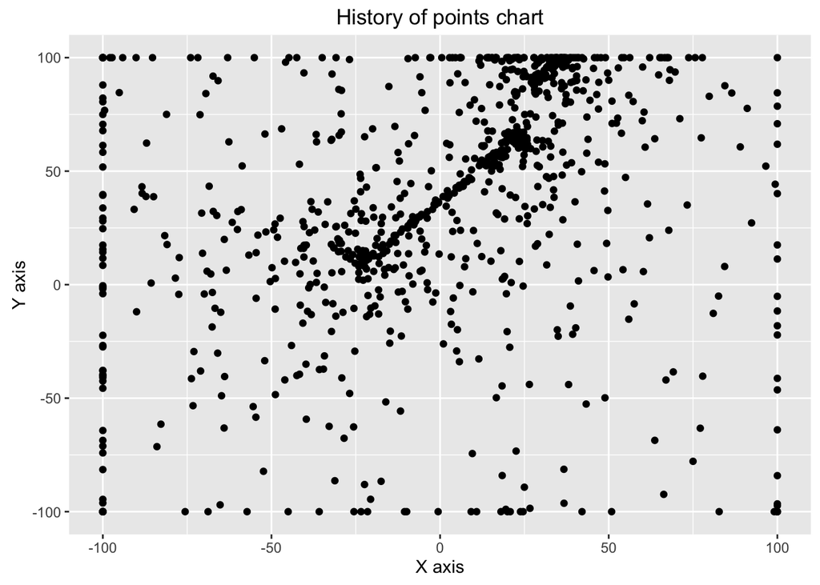

Wykres jakości od numeru iteracji:

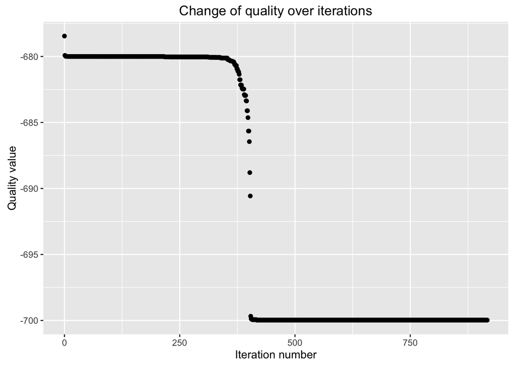

Zauważamy, że gdy algorytm znajdzie się w pewnym punkcie(otoczenie globalnego optimum), zaczyna bardzo gwałtownie zbiegać do niego co jest porządane i wynika za specyfiki badanego problemu.

Wykonaliśmy po 5 pomiarów błędów dla funkcji w każdym wymiarze.

##### 2 wymiary

```
## Średni błąd wyniósł:  0.03287165
```

|  | Result | Error | Relative error |
| --- | --- | --- | --- |
| 1 | -699.9673 | 0.0327114 | 4.67e-05 |
| 2 | -699.9667 | 0.0332685 | 4.75e-05 |
| 3 | -699.9605 | 0.0394777 | 5.64e-05 |
| 4 | -699.9868 | 0.0132229 | 1.89e-05 |
| 5 | -699.9543 | 0.0456778 | 6.53e-05 |

Dla 2 wymiarów algorytm niemalże bezbłędnie i bardzo szybko znajduje minimum globalne.

##### 5 wymiarów

```
## Średni błąd wyniósł:  20.02752
```

|  | Result | Error | Relative error |
| --- | --- | --- | --- |
| 1 | -679.9665 | 20.03346 | 0.0286192 |
| 2 | -679.9822 | 20.01782 | 0.0285969 |
| 3 | -679.9713 | 20.02873 | 0.0286125 |
| 4 | -679.9804 | 20.01963 | 0.0285995 |
| 5 | -679.9620 | 20.03799 | 0.0286257 |

Dla 5 wymiarów, algorytm nie był w stanie znaleźć optimum globalnego. Przypuszczalnie przy zmianie parametrów tak, aby kroki algorytmu były krótsze, byłby on w stanie poradzić sobie lepiej, jednakże czas obliczeń wydłużyłby się znacznie.

##### 20 wymiarów

```
## Średni błąd wyniósł:  20.71704
```

|  | Result | Error | Relative error |
| --- | --- | --- | --- |
| 1 | -679.3142 | 20.68585 | 0.0295512 |
| 2 | -679.2466 | 20.75335 | 0.0296476 |
| 3 | -679.2812 | 20.71877 | 0.0295982 |
| 4 | -679.2937 | 20.70635 | 0.0295805 |
| 5 | -679.2791 | 20.72089 | 0.0296013 |

Dla dwudziestu wymiarów algorytm sprawuje się podobnie jak dla 5 wymiarów. Zwiększenie wartości parametrów kMax i iterMax pozwoliłoby znaleźć optimum globalne.

### Problem Schwefel’s Function

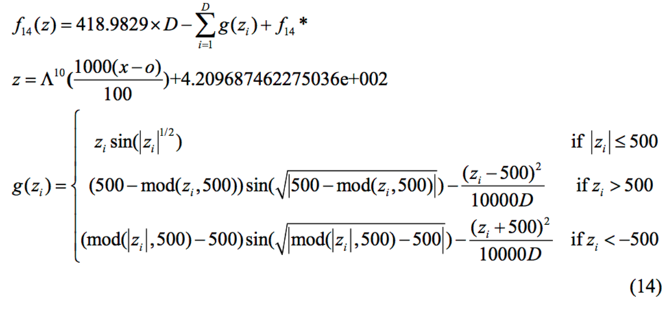

Funkcja ta jest multi-modalna, a jej liczba optimów lokalnych jest ogromna. Drugi najlepszy punkt jest znacząco oddalony od globalnego optimum, co sprawia że funkcja jest szczególnie interesująca do badania w kontekście znalezienia najlepszego punktu.

Wykres 3-D funkcji:

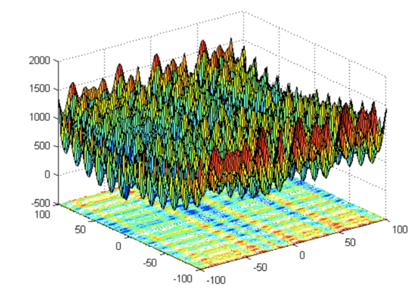

Mapa konturowa funkcji:

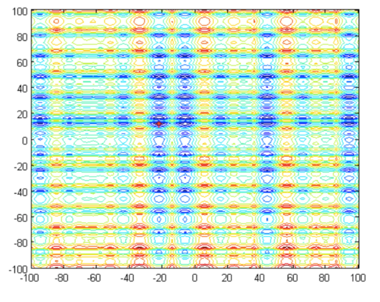

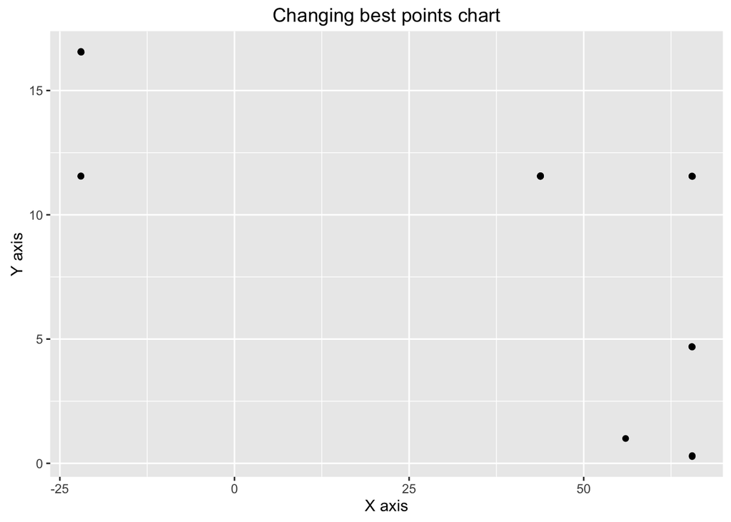

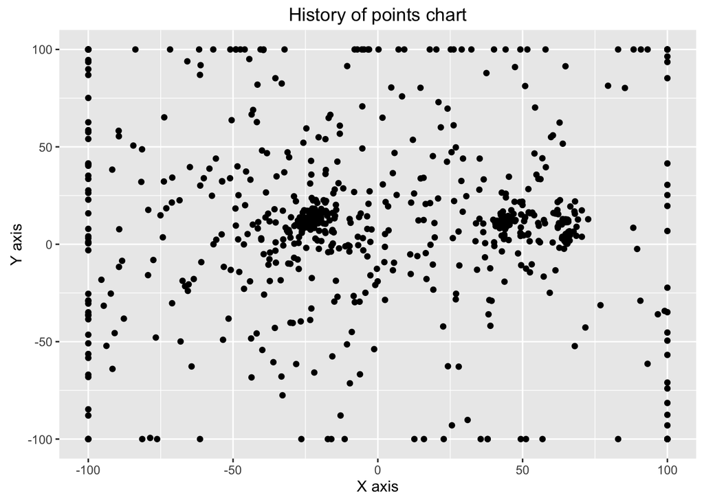

Wykres jakości od numeru iteracji:

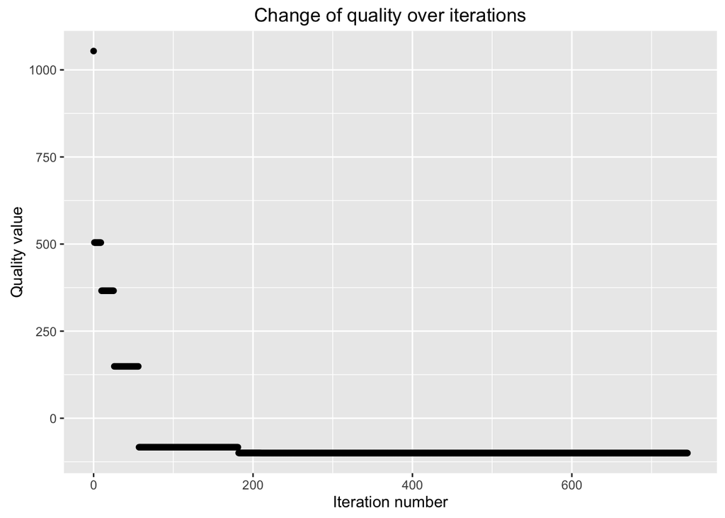

Wykonaliśmy po 5 pomiarów błędów dla funkcji w każdym wymiarze.

##### 2 wymiary

```
## Średni błąd wyniósł:  0.001098655
```

|  | Result | Error | Relative error |
| --- | --- | --- | --- |
| 1 | -99.99720 | 0.0027977 | 2.80e-05 |
| 2 | -99.99971 | 0.0002944 | 2.90e-06 |
| 3 | -99.99879 | 0.0012051 | 1.21e-05 |
| 4 | -99.99960 | 0.0004008 | 4.00e-06 |
| 5 | -99.99920 | 0.0007953 | 8.00e-06 |

Dla 2 wymiarów algorytm niemalże bezbłędnie i bardzo szybko znajduje minimum globalne.

##### 5 wymiarów

```
## Średni błąd wyniósł:  33.59011
```

|  | Result | Error | Relative error |
| --- | --- | --- | --- |
| 1 | -92.097156 | 7.902844 | 0.0790284 |
| 2 | -85.744154 | 14.255846 | 0.1425585 |
| 3 | -75.852700 | 24.147299 | 0.2414730 |
| 4 | 1.258728 | 101.258728 | 1.0125873 |
| 5 | -79.614149 | 20.385851 | 0.2038585 |

Średni błąd wynosi dość dużo, jednakże wynika to z jednego nieudanego przejścia algorytmu. W pozostałych przypadkach radzi sobie on całkiem dobrze dla 5 wymiarów, osiągając relatywnie mały błąd względny.

W celu zbadania wpływu współczynnika density na działanie algorytmu zwiekszyliśmy go do 1. Jak widać taki zabieg znacznie zwiększył uzyskany błąd:

```
## Średni błąd wyniósł:  93.9823
```

|  | Result | Error | Relative error |
| --- | --- | --- | --- |
| 1 | 27.19802 | 127.19802 | 1.2719802 |
| 2 | -35.24490 | 64.75510 | 0.6475510 |
| 3 | 43.47521 | 143.47521 | 1.4347521 |
| 4 | -54.55434 | 45.44566 | 0.4544566 |
| 5 | -10.96247 | 89.03753 | 0.8903753 |

##### 20 wymiarów

```
## Średni błąd wyniósł:  1890.342
```

|  | Result | Error | Relative error |
| --- | --- | --- | --- |
| 1 | 1724.775 | 1824.775 | 18.24775 |
| 2 | 2020.092 | 2120.092 | 21.20092 |
| 3 | 2023.999 | 2123.999 | 21.23999 |
| 4 | 1564.276 | 1664.276 | 16.64276 |
| 5 | 1618.566 | 1718.566 | 17.18566 |

Na ww. przypadku funkcja nie poradziła sobie najlepiej - błędy są duże. Przypuszczamy, że ma to związek ze zbyt “rzadkim” sprawdzaniem punktów, dla tylu wymiarów przeszukiwanie musiałoby trwać znacznie dłużej w przypadku tego problemu.

### Wnioski z eksperymentów

Wyniki uzyskane okazały się całkiem satysfakcjonujące. Uważamy, że barierą do uzyskania trochę lepszych wyników dla dużej liczby wymiarów był czas obliczeń, które były powtarzane wiele razy. Dla przypadkow dwuwymiarowych algorytm zachowuje się tak, jak tego oczekiwaliśmy - działa bardzo szybko, odnajduje globalne minima z łatwością, nie “utyka” w lokalnych.

Uważamy, że warto byłoby poeksperymentować również z innymi rozkładami liczb losowych, ponieważ w naszych eksperymentach korzystaliśmy jedynie z rozkładu normalnego.